# Lecture 15 notes

Today we’ll use genotypes from a VCF file to do genome-wide association analysis and genomic selection.

## Packages for today

Remember to use `install.packages` for anything you need to install from CRAN, and `BiocManager::install` for anything you need to install from Bioconductor.

```r
# On CRAN
library(rrBLUP)
library(Matrix)
library(bigmemory)
library(biganalytics)
library(compiler)
library(gplots)
library(LDheatmap)
library(genetics)
library(ape)
library(EMMREML)
library(scatterplot3d)

# On Bioconductor
library(VariantAnnotation)
library(snpStats)
library(multtest)
```

We’ll also load two R scripts off the internet in order to use FarmCPU.

```r
source("http://zzlab.net/GAPIT/gapit_functions.txt")
source("http://zzlab.net/FarmCPU/FarmCPU_functions.txt")
```

## Phenotype file

On compass, I put a CSV with phenotypic data for the *Miscanthus sinensis* collection. For every accession, it contains best linear unbiased predictors (BLUPs) of the phenotypic values across multiple replicates and field trial locations.

```r
stem_blups <- read.csv("Msinensis_blups.csv", header = TRUE,
                       stringsAsFactors = FALSE)

# throw out those with missing data
stem_blups <- stem_blups[!is.na(stem_blups$Stem_diameter),]

head(stem_blups)
```

```
##             Genotype Stem_diameter Biomass_yield
## 1              Akeno          0.86          7.09
## 2 CANE9233-US47-0011         -0.04         -7.19
## 4      DC-2010-001-E         -0.34         -2.18
## 5              Gunma          0.40          6.77
## 7         JM0001.001         -0.24         -4.22
## 8         JM0001.002          0.00         -1.18
```

## Genotypes

We have worked with a few versions of the dataset, but here we will stick with the output from Lab 5 since it is relatively small.

```r
myparam <- ScanVcfParam(fixed = "ALT", info = NA, geno = "GT")
myvcf <- readVcf("Msinensis_chr01genes_filtered.vcf", param = myparam)

myvcf
```

```
## class: CollapsedVCF
## dim: 6135 585
## rowRanges(vcf):
##   GRanges with 3 metadata columns: paramRangeID, REF, ALT
## info(vcf):
##   DataFrame with 0 columns:
## geno(vcf):
##   SimpleList of length 1: GT
## geno(header(vcf)):
##       Number Type   Description
##    GT 1      String Genotype
```

For statistical analysis, we will want genotypes in numeric format.

```r
chr01mat <- genotypeToSnpMatrix(myvcf)
```

```
## non-single nucleotide variations are set to NA
```

```r
chr01num <- as(chr01mat$genotypes, "numeric")
chr01num[1:10,1:10]
```

```
##                       S01_150928 S01_150929 S01_167873 S01_167936
## KMS207-8                       0          0          0          1
## JM0051.003                     0          0          0          0
## JM0034.001                     0          0          0          0
## JM0220.001                     0          0          0          1
## NC-2010-003-001                0          0          0          0
## JM0026.001                     0          0          0          0
## JM0026.002                     0          0          0          0
## PI294605-US64-0007-01          0          0          0          0
## JM0058.001                     0          0          1          0
## UI10-00086-Silberfeil          0          0          0          1
##                       S01_168305 S01_168307 S01_168319 S01_168325
## KMS207-8                       0          0          0          0
## JM0051.003                     0          0          0          1
## JM0034.001                     0          0          0          1
## JM0220.001                     0          0          0          0
## NC-2010-003-001                0          0          0          0
## JM0026.001                     0          0          0          1
## JM0026.002                     0          0          0          1
## PI294605-US64-0007-01          1          0          0          0
## JM0058.001                     0          0          0          0
## UI10-00086-Silberfeil          0          0          0          0
##                       S01_168369 S01_168371
## KMS207-8                       0          0
## JM0051.003                     0          0
## JM0034.001                     0          0
## JM0220.001                     0          0
## NC-2010-003-001                0          0
## JM0026.001                     0          0
## JM0026.002                     0          0
## PI294605-US64-0007-01          0          0
## JM0058.001                     0          0
## UI10-00086-Silberfeil          0          0
```

## Matching the datasets

Let’s get a list of accessions that were in both the phenotypic and genotypic dataset, to make sure we are working with the same samples.

```r
mysamples <- stem_blups$Genotype[stem_blups$Genotype %in% row.names(chr01num)]
str(mysamples)
```

```
##  chr [1:557] "Akeno" "CANE9233-US47-0011" "DC-2010-001-E" "Gunma" ...
```

Then we can subset both the genotypic and phenotypic dataset by this vector.

```r
stem_blups <- stem_blups[match(mysamples, stem_blups$Genotype),]
chr01num <- chr01num[mysamples, ]

# sanity check
head(stem_blups)
```

```
##             Genotype Stem_diameter Biomass_yield
## 1              Akeno          0.86          7.09
## 2 CANE9233-US47-0011         -0.04         -7.19
## 4      DC-2010-001-E         -0.34         -2.18
## 5              Gunma          0.40          6.77
## 7         JM0001.001         -0.24         -4.22
## 8         JM0001.002          0.00         -1.18
```

```r
chr01num[1:10,1:5]
```

```
##                    S01_150928 S01_150929 S01_167873 S01_167936 S01_168305
## Akeno                       0          0          0          0          0
## CANE9233-US47-0011          0          0          0          0          0
## DC-2010-001-E               0          0          0          1          0
## Gunma                       0          0          0          0          0
## JM0001.001                  0          0          0          0          0
## JM0001.002                  0          0          0          0          0
## JM0001.003                  0          0          0          0          0
## JM0022.001                 NA         NA          0          0          0
## JM0022.002                  0          0          0          0          0
## JM0022.003                  0          0          0          0          0
```

```r
identical(stem_blups$Genotype, rownames(chr01num))
```

```
## [1] TRUE
```

## Subsetting by minor allele frequency

Now that we have the genotypes in a numeric matrix, we can calculate allele frequencies quickly. Every individual can have up to two copies of an allele, so allele frequency in the population is the mean value for the SNP divided by two.

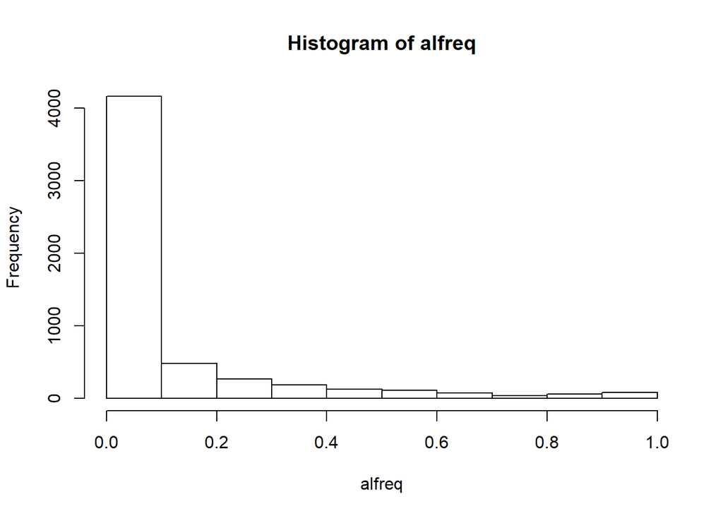

```r
alfreq <- colMeans(chr01num, na.rm = TRUE)/2
hist(alfreq)
```

Since zero is the reference allele, it also tends to be the common allele, but there are some SNPs where the common allele is the alternative allele.

By eliminating SNPs where the minor allele frequency is less than 0.05, we not only eliminate SNPs where we lack statistical power to detect true associations, but also eliminate false positives that can occur when an individual with an extreme phenotype also happens to be the only individual posessing a particular allele.

```r
keepSNPs <- which(alfreq > 0.05 & alfreq < 0.95)

chr01num_filt <- chr01num[, keepSNPs]
```

## Marker imputation

Due to our filtering in Week 5, about 2% of genotypes are missing in this dataset.

```r
mean(is.na(chr01num_filt))
```

```
## [1] 0.02171488
```

Imputation can be performed using linkage disequilibrium among nearby markers. However, there is very little linkage disequilibrium in this dataset, and so we can get a more accurate result using relatedness for imputation. We will use `rrBLUP` to simultaneously calculate the relationship matrix and impute missing genotypes. Instead of genotypes being on a scale of 0 to 2, for `rrBLUP` they must be on a scale of -1 to 1.

```r
Msi_A <- A.mat(chr01num_filt - 1, impute.method = "EM", return.imputed = TRUE)
```

```
## [1] "A.mat converging:"
## [1] 0.00418
```

```r
chr01num_imputed <- Msi_A$imputed + 1
```

## Formatting for FarmCPU

See http://www.zzlab.net/FarmCPU/FarmCPU_help_document.pdf

For both the genotypes and phenotypes, we need a column called “taxa”.

```r
names(stem_blups)[1] <- "Taxa"
myGD <- data.frame(taxa = mysamples, chr01num_imputed)
```

Then we also need a data frame with the alignment information. We could get it out of the `rowRanges` from the VCF, or in this case parse it from the SNP names.

```r
snpnames <- colnames(chr01num_imputed)
myGM <- data.frame(SNP = snpnames,
                   Chromosome = as.integer(substring(snpnames, 2, 3)),
                   Position = as.integer(sub("^S.._", "", snpnames)))
head(myGM)
```

```
##          SNP Chromosome Position
## 1 S01_167936          1   167936
## 2 S01_168325          1   168325
## 3 S01_212989          1   212989
## 4 S01_260596          1   260596
## 5 S01_350972          1   350972
## 6 S01_350984          1   350984
```

## Running FarmCPU

Now we can run FarmCPU. Make a folder inside your working directory called “FarmCPU” and move into it. Output files will be written there.

```r
setwd("FarmCPU")

results <- FarmCPU(Y = stem_blups[,1:2], GM = myGM, GD = myGD)
```

```
## [1] "--------------------- Welcome to FarmCPU ----------------------------"
## [1] "FarmCPU Started..."
## [1] "Current loop: 1 out of maximum of 10"
## [1] "seqQTN"
## NULL
## [1] "scanning..."
## [1] "number of covariates in current loop is:"
## [1] 0
## [1] "Current loop: 2 out of maximum of 10"
## [1] "optimizing possible QTNs..."
## [1] "seqQTN"
## [1]  184 1334 1052 1991
## [1] "scanning..."
## [1] "number of covariates in current loop is:"
## [1] 4
```

[output cut: 32 more lines]

```
## [1] "GAPIT.Manhattan accomplished successfully!zw"
```

```
## [1] "**********FarmCPU ACCOMPLISHED SUCCESSFULLY**********"
```

## Examining the results

A Manhattan plot was output to the FarmCPU directory, and can be opened and examined. Which SNPs were significant after multiple testing correction?

```r
results$GWAS$fdr <- p.adjust(results$GWAS$P.value, method = "fdr")
sigsnps <- as.character(results$GWAS$SNP[which(results$GWAS$fdr < 0.05)])
sigsnps
```

```
##  [1] "S01_1232290"   "S01_1899114"   "S01_3319891"   "S01_6218568"
##  [5] "S01_21906642"  "S01_46550971"  "S01_52316163"  "S01_83484316"
##  [9] "S01_95176520"  "S01_98041147"  "S01_114944054" "S01_139322066"
## [13] "S01_144395173" "S01_149891525"
```

It can be helpful to make a scatter plot of genotype vs. phenotype.

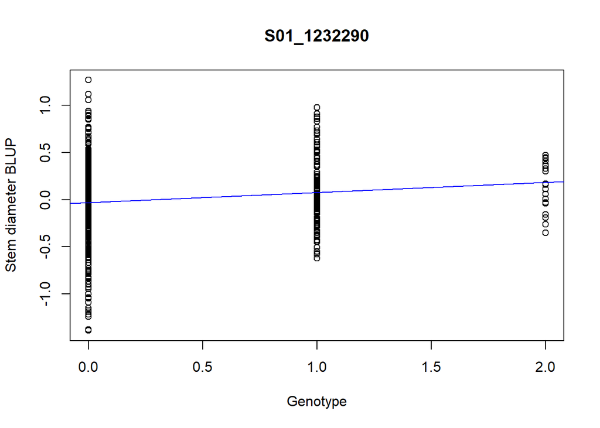

```r
mySNP <- sigsnps[1]
plot(chr01num_imputed[,mySNP], stem_blups$Stem_diameter,
     xlab = "Genotype", ylab = "Stem diameter BLUP",
     main = mySNP)
abline(lm(stem_blups$Stem_diameter ~ chr01num_imputed[,mySNP]), col = "blue")
```

We could also look up candidate genes in a `TxDb` object, using what we have learned in previous weeks.

## Genomic prediction

The GWAS identifies locations where we have the statistical power to identify an association. How well can we predict stem diameter from these SNPs?

```r
myLM <- lm(stem_blups$Stem_diameter ~ chr01num_imputed[, sigsnps])
summary(myLM)
```

```
##
## Call:
## lm(formula = stem_blups$Stem_diameter ~ chr01num_imputed[, sigsnps])
##
## Residuals:
##      Min       1Q   Median       3Q      Max
## -0.87725 -0.22438 -0.01369  0.22396  1.12472
##
## Coefficients:
##                                          Estimate Std. Error t value
## (Intercept)                              -0.18815    0.05274  -3.568
## chr01num_imputed[, sigsnps]S01_1232290    0.08235    0.02810   2.931
## chr01num_imputed[, sigsnps]S01_1899114    0.41993    0.05711   7.353
## chr01num_imputed[, sigsnps]S01_3319891    0.13003    0.02651   4.906
## chr01num_imputed[, sigsnps]S01_6218568   -0.13773    0.04273  -3.223
## chr01num_imputed[, sigsnps]S01_21906642   0.07153    0.02039   3.509
## chr01num_imputed[, sigsnps]S01_46550971  -0.10703    0.01844  -5.804
## chr01num_imputed[, sigsnps]S01_52316163   0.08368    0.02132   3.925
## chr01num_imputed[, sigsnps]S01_83484316  -0.11776    0.03639  -3.236
## chr01num_imputed[, sigsnps]S01_95176520  -0.17056    0.04050  -4.211
## chr01num_imputed[, sigsnps]S01_98041147  -0.08358    0.02795  -2.990
## chr01num_imputed[, sigsnps]S01_114944054 -0.21050    0.04631  -4.546
## chr01num_imputed[, sigsnps]S01_139322066 -0.16882    0.03903  -4.325
## chr01num_imputed[, sigsnps]S01_144395173  0.14465    0.03415   4.236
## chr01num_imputed[, sigsnps]S01_149891525  0.08519    0.03298   2.583
##                                          Pr(>|t|)
## (Intercept)                              0.000392 ***
## chr01num_imputed[, sigsnps]S01_1232290   0.003524 **
## chr01num_imputed[, sigsnps]S01_1899114   7.20e-13 ***
## chr01num_imputed[, sigsnps]S01_3319891   1.23e-06 ***
## chr01num_imputed[, sigsnps]S01_6218568   0.001345 **
## chr01num_imputed[, sigsnps]S01_21906642  0.000487 ***
## chr01num_imputed[, sigsnps]S01_46550971  1.10e-08 ***
## chr01num_imputed[, sigsnps]S01_52316163  9.81e-05 ***
## chr01num_imputed[, sigsnps]S01_83484316  0.001287 **
## chr01num_imputed[, sigsnps]S01_95176520  2.97e-05 ***
## chr01num_imputed[, sigsnps]S01_98041147  0.002914 **
## chr01num_imputed[, sigsnps]S01_114944054 6.75e-06 ***
## chr01num_imputed[, sigsnps]S01_139322066 1.81e-05 ***
## chr01num_imputed[, sigsnps]S01_144395173 2.67e-05 ***
## chr01num_imputed[, sigsnps]S01_149891525 0.010048 *
## ---
## Signif. codes:  0 '***' 0.001 '**' 0.01 '*' 0.05 '.' 0.1 ' ' 1
##
## Residual standard error: 0.326 on 542 degrees of freedom
## Multiple R-squared:  0.3932, Adjusted R-squared:  0.3775
## F-statistic: 25.08 on 14 and 542 DF,  p-value: < 2.2e-16
```

We get an adjusted R-squared of 38%. This is certainly an overestimate, especially since we are only looking at one out of nineteen chromosomes. It is likely that these SNPs also carry a signal of population structure, reflecting SNPs across the genome that affect stem diameter and have a similar pattern of diversity.

Genomic prediction uses all available markers at once, assuming there are many small effects that we can’t detect with GWAS, and also using the effects of population structure and relatedness across all SNPs.

If we assume that every marker in the genome has equal variance in terms of how much it is impacting the phenotype, we can reduce all markers to an additive relationship matrix and predict phenotypes from that. The relationship matrix that we made before is what we will put into the genomic prediction function.

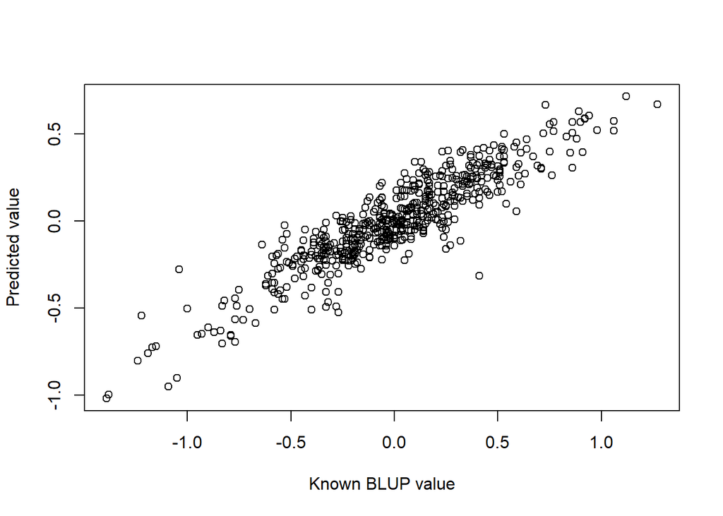

```r
mypred <- kin.blup(stem_blups, "Taxa", "Stem_diameter", K = Msi_A$A)
plot(stem_blups$Stem_diameter, mypred$pred, xlab = "Known BLUP value",
     ylab = "Predicted value")
```

```r
cor(stem_blups$Stem_diameter, mypred$pred) ^ 2
```

```
## [1] 0.8275319
```

Now we have explained 83% of the variance, as opposed to 38%.

## Cross validation

This model was cheating slightly, since all of the values that we were predicting also went into the model. We can try something else called five-fold cross validation, where we see what happens when we mask 1/5 of the phenotypes. We will do random subsets each time, and try it ten times, although 100 or more would be advisable in a real situation.

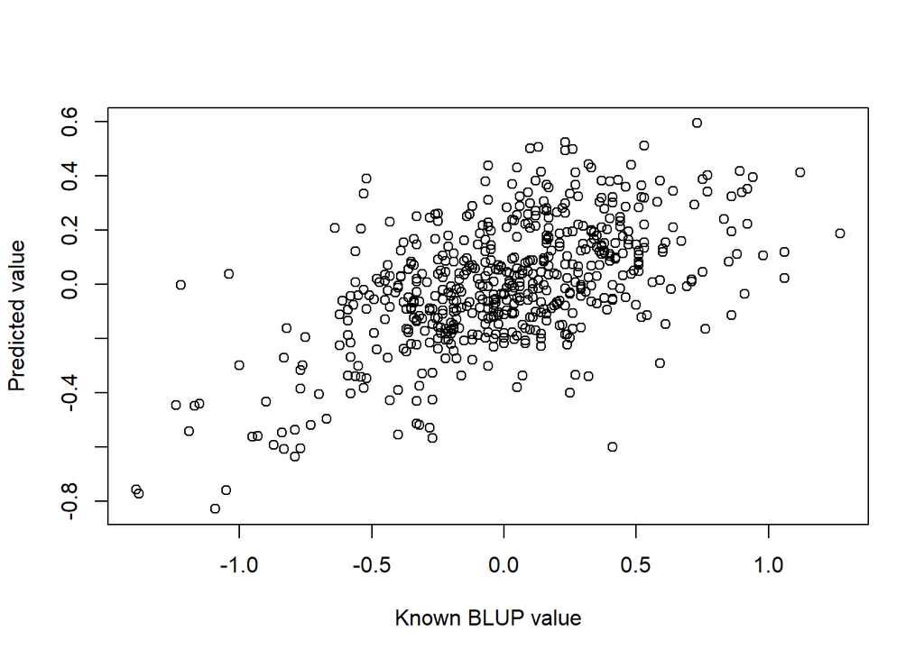

```r
group_indices <- list(1:111,
                      112:222,
                      223:333,
                      334:445,
                      446:557)

nreps <- 10 # number of reps

# matrix to hold results
GEBVs <- matrix(nrow = length(mysamples), ncol = nreps,
                dimnames = list(mysamples, NULL))
for(i in 1:nreps){
  # randomly rearrange sample order
  thissamples <- sample(mysamples)
  for(j in 1:5){
    # determine which samples to mask
    masksamples <- thissamples[group_indices[[j]]]

    # get phenotypes and make the appropriate ones NA
    thisphen <- stem_blups[, 1:2]
    thisphen[match(masksamples, thisphen$Taxa), "Stem_diameter"] <- NA

    # run genomic prediction
    thispred <- kin.blup(thisphen, "Taxa", "Stem_diameter", K = Msi_A$A)

    # fill in matrix
    GEBVs[masksamples, i] <- thispred$pred[masksamples]
  }
}

# get mean GEBVs and see how they compare to real values
mean_GEBVs <- rowMeans(GEBVs)
plot(stem_blups$Stem_diameter, mean_GEBVs, xlab = "Known BLUP value",
     ylab = "Predicted value")
```

```r
cor(stem_blups$Stem_diameter, mean_GEBVs) ^ 2
```

```
## [1] 0.3283907
```

Here we just see 32% of variation explained.